# ps2

Ohad Raviv

02/05/2021

```r
library(magrittr)
library(haven)
library(Hmisc)
library(tidyverse)
```

```r
library(ggplot2)
library(magrittr)
library(dplyr)
library(stargazer)
library(plyr)
library(ri)
library(scales)
library(readstata13)
library(gridExtra)
library(sandwich)
library(lmtest)
stocks <- read.dta13("data_part1.dta")
stocks$rf <- 0.0041
stocks$rM_rf <- stocks$r_M - stocks$rf
stocks$rA_rf <- stocks$r_A - stocks$rf
stocks$rB_rf <- stocks$r_B - stocks$rf
head(stocks)
```

```
##        date gspc_sp500 mcd_mcdonalds gld_spdrgoldshares gnw_genworthfinancial
## 1 12/1/2004    1173.78         30.90              45.28                 26.40
## 2  1/1/2005    1211.92         31.60              42.98                 27.00
## 3  2/1/2005    1181.27         32.05              42.09                 26.54
## 4  3/1/2005    1203.60         33.02              43.30                 28.20
## 5  4/1/2005    1180.59         31.20              42.60                 27.65
## 6  5/1/2005    1156.85         29.12              43.13                 28.00
##   ms_morganstanley         r_M r_mcd_mcdonalds         r_A         r_C
## 1            51.00  0.03855962      0.06368332  0.01913118  0.09999999
## 2            55.97  0.03249332      0.02265375 -0.05079504  0.02272729
## 3            56.45 -0.02529047      0.01424047 -0.02070729 -0.01703700
## 4            56.47  0.01890335      0.03026525  0.02874790  0.06254709
## 5            57.48 -0.01911766     -0.05511810 -0.01616630 -0.01950359
## 6            50.30 -0.02010858     -0.06666666  0.01244138  0.01265824
##             r_B     rf       rM_rf        rA_rf        rB_rf
## 1 -0.0058479384 0.0041  0.03445962  0.015031184 -0.009947938
## 2  0.0974510014 0.0041  0.02839332 -0.054895037  0.093351001
## 3  0.0085760141 0.0041 -0.02939047 -0.024807292  0.004476014
## 4  0.0003543039 0.0041  0.01480335  0.024647899 -0.003745696
## 5  0.0178855732 0.0041 -0.02321766 -0.020266300  0.013785573
## 6 -0.1249130219 0.0041 -0.02420858  0.008341376 -0.129013022
```

```r
sampleVar1 <- cov(stocks[c("r_A", "r_B", "r_M")])
sampleVar2 <- cov(stocks[c("rA_rf", "rB_rf", "rM_rf")])

sampleVar1
```

```
##               r_A           r_B          r_M
## r_A  2.905690e-03 -0.0003844852 1.171093e-05
## r_B -3.844852e-04  0.0105434580 2.646404e-03
## r_M  1.171093e-05  0.0026464043 1.615544e-03
```

```r
sampleVar2
```

```
##               rA_rf         rB_rf        rM_rf
## rA_rf  2.905690e-03 -0.0003844852 1.171093e-05
## rB_rf -3.844852e-04  0.0105434580 2.646404e-03
## rM_rf  1.171093e-05  0.0026464043 1.615544e-03
```

As we can see, both of the sample variences are equal. That’s because $r_{f}$ is constant and we know that var(X + c) = var(X)

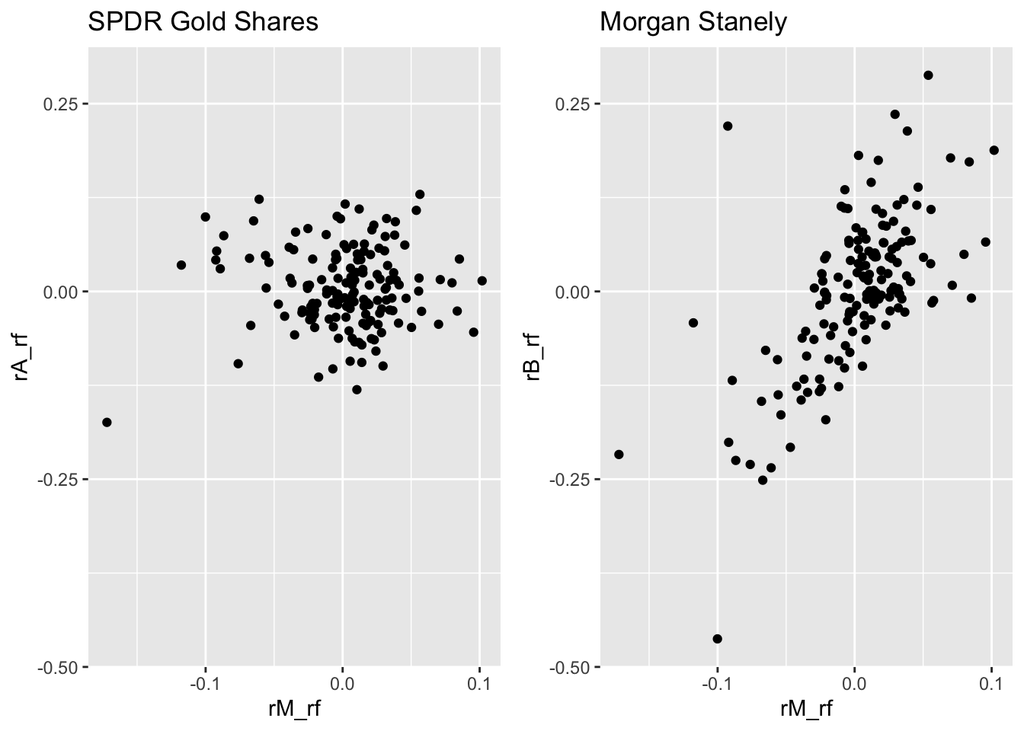

```r
y.lim <- c(min(stocks$rA_rf,stocks$rB_rf), max(stocks$rA_rf,stocks$rB_rf))
plot1 <- ggplot(stocks, aes(x=rM_rf, y=rA_rf)) + geom_point() + ylim(y.lim) +ggtitle("SPDR Gold Shares")
plot2 <- ggplot(stocks, aes(x=rM_rf, y=rB_rf)) + geom_point() + ylim(y.lim) +ggtitle("Morgan Stanely")
grid.arrange(plot1, plot2, ncol=2)
```

As we can learn from the graphs, the excess returns of Morgan Stanley are more strongly associated with the market returns. When the data shows that the market returns are rising - the excess returns of Morgan Stanley also rise. On the other hand, when the marekt returns are rising the SPDR Gold Share returns stay practically the same.

```r
#define X, Y
Y_1 <- stocks$rA_rf
Y_2 <- stocks$rB_rf
X <- stocks$rM_rf
intercept <- rep(1, length(Y_1)) #setting the p=0
X <- cbind(intercept, X)

r_A <- stocks$r_A
r_B <- stocks$r_B
r_M <- stocks$r_M

#projection of X on Y
coeff1 <- solve(t(X) %*% X) %*% t(X) %*% Y_1
reg.beta1 <- round(coeff1[2],3)
cov.r_A <- round(cov(r_A, r_M)/var(r_M),3)


coeff2 <- solve(t(X) %*% X) %*% t(X) %*% Y_2
reg.beta2 <- round(coeff2[2],3)
cov.r_B <- round(cov(r_B, r_M)/var(r_M),3)

cat(paste0("For beta_A: ",cov.r_A, " = ", reg.beta1))
```

```
## For beta_A: 0.007 = 0.007
```

```r
cat(paste0("For beta_B: ",cov.r_B, " = ", reg.beta2))
```

```
## For beta_B: 1.638 = 1.638
```

2. We can see that if E($r_{j}$) = $β_{j}$ (E( $r_{M}$) - $r_{f}$ ) then Y = ($r_{A}$ - $r_{f}$), X = ($r_{M}$ - $r_{f}$ ) and we already know E( $r_{j}$ ) - $r_{f}$ = $β_{j}$(E($r_{M}$) - $r_{f}) -> E(Y) = $β_{j}$ E(X)

($r_{jt}$ - $r_{f}$) = $α_{j}$ + $β_{j}$ ($r_{Mt}$ - $r_{f}$) + $ϵ_{jt}$)

and by the linearity of expectation: E($r_{jt}$) _ $r_{f}$ = E($α_{j}$) + $β_{j}$ (E($r_{Mt}$) - $r{f}$) + E($r_{jt}$) $r_{f}$ is constant, E($ϵ_{jt}$) is 0. so if equation 1 holds then we nkow $a_{j}$ is 0.

```r
Y_1 <- stocks$rA_rf
Y_2 <- stocks$rB_rf
X <- stocks$rM_rf

r_A <- stocks$r_A
r_B <- stocks$r_B
r_M <- stocks$r_M


reg.model1 <- lm(Y_1~X)
reg.beta1 <- round(reg.model1$coefficients[2],3)
reg.alpha1 <- reg.model1$coefficients[1]

reg.model2 <- lm(Y_2~X)
reg.beta2 <- round(reg.model2$coefficients[2],3)
reg.alpha2 <- reg.model2$coefficients[1]
```

iv:

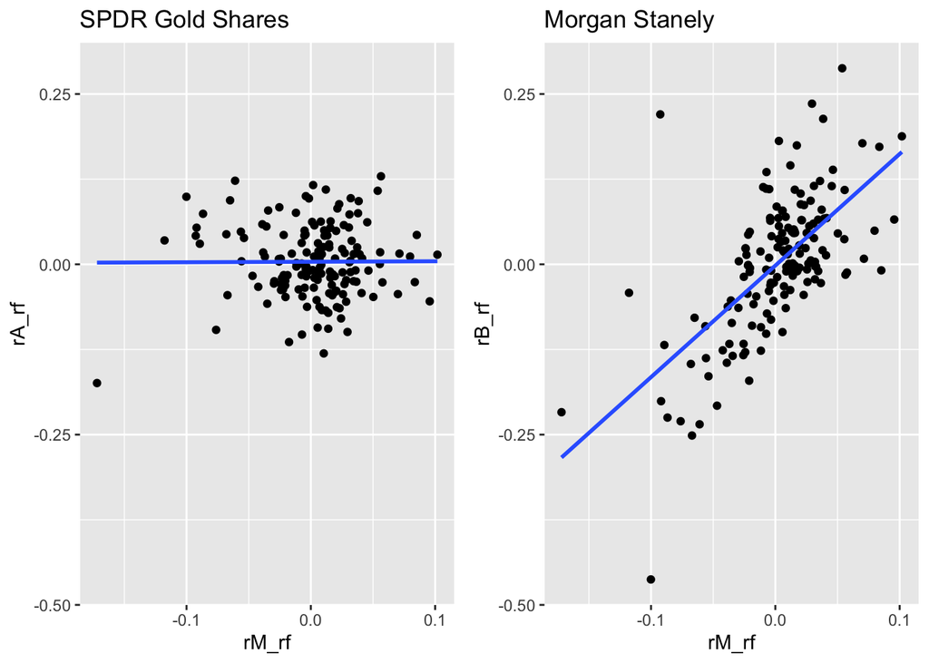

```r
y.lim <- c(min(stocks$rA_rf,stocks$rB_rf), max(stocks$rA_rf,stocks$rB_rf))
plot1 <- ggplot(stocks, aes(x=rM_rf, y=rA_rf)) + geom_point()+geom_smooth(method = "lm", se = FALSE) + ylim(y.lim) +ggtitle("SPDR Gold Shares")
plot2 <- ggplot(stocks, aes(x=rM_rf, y=rB_rf)) + geom_point() +geom_smooth(method = "lm", se = FALSE) + ylim(y.lim) +ggtitle("Morgan Stanely")
grid.arrange(plot1, plot2, ncol=2)
```

v. Since it is less correlated with the market performance, I would recommend to a worried investor to invest her money in SPDR.

Part 2: 1)

```r
mutualReturns <- read.dta13("data_part2.dta")
mutualReturns_length <- length(colnames(mutualReturns))

mutualReturns[2:mutualReturns_length] <- lapply(mutualReturns[2:mutualReturns_length], function(x) x-0.0041)
```

```r
SQPX.reg <- lm(r_swppx ~ r_M, data=mutualReturns)
SQPX.alpha <- SQPX.reg$coefficients[1]
SQPX.beta <- SQPX.reg$coefficients[2]
print(paste0("alpha is: ", round(SQPX.alpha,4), " beta is: ",round(SQPX.beta,4)))
```

```
## [1] "alpha is: 0.0018 beta is: 0.9691"
```

1. Looking at equation 2, we see that the variance of the residuals may vary by each sample. Homescedasticity may be assume only if the variance of the residuals is distinct and therefore we can’t assume homoscedasticity.

In the following plot - if the data was homoscedastic we would expect a relatively horizontal line with equally spraed points around it. We can see that this is not the case and hence we have a heteroscedasticity problem.

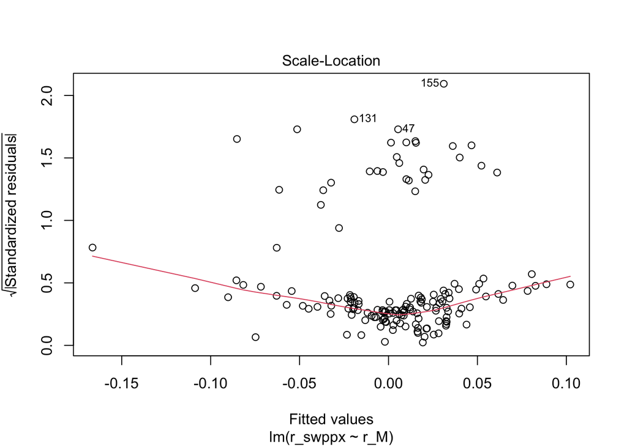

```r
plot(SQPX.reg, which=3)
```

b. We shall now test the null hypothesis that α = 0 with a 0.1 significance level:

```r
#vcovHC for heteroscedastic-robust
SQPX.alpha.hat <- SQPX.alpha
SQPX.alpha.se <- sqrt(vcovHC(SQPX.reg)[1,1])
test.stat <- abs(SQPX.alpha.hat/SQPX.alpha.se)
SQPX.alpha.pval <- 2*(1-pt(test.stat,dim(mutualReturns)[1]-1))

#Will we reject the null hypothesis at 0.1 level?
test.stat > qt(0.95, dim(mutualReturns)[1]-1)
```

```
## (Intercept)
##        TRUE
```

```r
SQPX.alpha.pval < 0.1
```

```
## (Intercept)
##        TRUE
```

We reject the null hypothesis at 0.1 significance level that α = 0.

```r
SQPX.CI <- coefci(SQPX.reg, stocks = dim(mutualReturns)[1]-1, level=.90, vcov = vcovHC)[1,]
SQPX.CI
```

```
##          5 %         95 %
## 0.0005193562 0.0030194780
```

4. We can conclude that α will be greater than 0, but not by a lot - in 90% chance alpha will be between 5.1940146^{-4} and 0.0030194. It’s ok but we can’t say that it would outperform the market, investor i will probably invest in this fund.

```r
Hypo.data <- function(stocks, fund, r_M, a, fund_name) {
  fund.reg <- lm(fund ~ r_M)
  fund.alpha.hat <- fund.reg$coefficients[1]
  fund.beta.hat <- fund.reg$coefficients[2]
  fund.alpha.se <- sqrt(vcovHC(fund.reg)[1,1])

  test.stat <- abs(fund.alpha.hat/fund.alpha.se)
  fund.alpha.pval <- 2*(1-pt(test.stat,dim(stocks)[1]-1))
  null_status <- test.stat > qt(1-(a/2), dim(stocks)[1]-1)
  # fund.alpha.pval < a

  fund.CI <- coefci(fund.reg, df = dim(stocks)[1]-1, level=1-a, vcov = vcovHC)[1,]
  ans <- data.frame(fund = fund_name, alpha= round(fund.alpha.hat,4), beta= round(fund.beta.hat,4), nullHypo = null_status, pval = round(fund.alpha.pval,4))
  return(ans)
}
```

```r
data <- data.frame(fund = NA, alpha= NA, beta= NA, nullHypo = NA, pval = NA)
for (col in c(1:10)) {
  tmpData <- (Hypo.data(mutualReturns,mutualReturns[,col+2], mutualReturns$r_M, 0.1, names(mutualReturns)[3:12][col]))
  data <- rbind(data, tmpData)
}
rownames(data) <- NULL
data <- na.omit(data)
data
```

```
##       fund   alpha    beta nullHypo   pval
## 2  r_fbalx  0.0013  0.6659    FALSE 0.3905
## 3  r_fsiix -0.0009  1.0689    FALSE 0.6571
## 4  r_swppx  0.0018  0.9691     TRUE 0.0204
## 5  r_swssx  0.0021  1.1603    FALSE 0.4730
## 6  r_swtsx  0.0020  0.9905     TRUE 0.0105
## 7  r_trrbx  0.0005  0.7717    FALSE 0.7259
## 8  r_vbisx -0.0019 -0.0101     TRUE 0.0000
## 9  r_vbmfx -0.0010 -0.0017    FALSE 0.1850
## 10 r_veiex  0.0011  1.2630    FALSE 0.7223
## 11 r_vgsix  0.0023  1.2085    FALSE 0.5500
```

We shall reject three of the funds for the null hypothesis, these are the funds: vbisx, swtsx, swppx. Using the CAPM model if α>0 then we would expect the asset to have a higher expected return than the market. So I can say that the alpha will be the best indicator for returns, the bigger the alpha the bigger the returns we will expect. The fund which surprises me for making it into the Time’s 50 best mutual Funds in 2018 are those with both a negative alpha and a rejection of the null hypotheses - there is only one and it is vbisx.

1. Because we have 10 hypotheses testing to perform and we check with a significance level of 0.1, if only one null hypothesis would be true, then we would get a proportion of a tenth which equals 0.1.
2. If the two null hypothesis are independent then P(A ∩ B) = P(A)P(B) then we know: P(reject any null) = 1 - P(reject no null) =P(don’t reject H0 and don’t reject H0) = 1 - (1 - α)^2 = 0.19 which is greater than 0.1.

It might be exactly equal to 0.1 if the two null hypothesis are fully dependent: P(A∩B)=min(P(a),P(b))0.1

3. According to the proof shown in the previous section: P(reject any null) = 1 - P(reject no null) =P(don;t reject H0 and … and don’t reject H0) = 1 - (1 - α)^n = 1 - (1 - 0.1)^10 = 0.65

It could be equal 0.1 in the same way as explained in b.

```r
data$bonferon <- data$pval < (0.1/10)
data
```

```
##       fund   alpha    beta nullHypo   pval bonferon
## 2  r_fbalx  0.0013  0.6659    FALSE 0.3905    FALSE
## 3  r_fsiix -0.0009  1.0689    FALSE 0.6571    FALSE
## 4  r_swppx  0.0018  0.9691     TRUE 0.0204    FALSE
## 5  r_swssx  0.0021  1.1603    FALSE 0.4730    FALSE
## 6  r_swtsx  0.0020  0.9905     TRUE 0.0105    FALSE
## 7  r_trrbx  0.0005  0.7717    FALSE 0.7259    FALSE
## 8  r_vbisx -0.0019 -0.0101     TRUE 0.0000     TRUE
## 9  r_vbmfx -0.0010 -0.0017    FALSE 0.1850    FALSE
## 10 r_veiex  0.0011  1.2630    FALSE 0.7223    FALSE
## 11 r_vgsix  0.0023  1.2085    FALSE 0.5500    FALSE
```

As we can see from the data, we will reject only one null hypothesis - vbisx fund.

```r
alpha= 0.1
data <- arrange(data, pval)
data$k <- c(1:nrow(data))
data$RejHypK <- ifelse((alpha/(10+1-data$k))>data$pval, TRUE, FALSE)
#for k+2 the process ends here.
data
```

```
##       fund   alpha    beta nullHypo   pval bonferon  k RejHypK
## 1  r_vbisx -0.0019 -0.0101     TRUE 0.0000     TRUE  1    TRUE
## 2  r_swtsx  0.0020  0.9905     TRUE 0.0105    FALSE  2    TRUE
## 3  r_swppx  0.0018  0.9691     TRUE 0.0204    FALSE  3   FALSE
## 4  r_vbmfx -0.0010 -0.0017    FALSE 0.1850    FALSE  4   FALSE
## 5  r_fbalx  0.0013  0.6659    FALSE 0.3905    FALSE  5   FALSE
## 6  r_swssx  0.0021  1.1603    FALSE 0.4730    FALSE  6   FALSE
## 7  r_vgsix  0.0023  1.2085    FALSE 0.5500    FALSE  7   FALSE
## 8  r_fsiix -0.0009  1.0689    FALSE 0.6571    FALSE  8   FALSE
## 9  r_veiex  0.0011  1.2630    FALSE 0.7223    FALSE  9   FALSE
## 10 r_trrbx  0.0005  0.7717    FALSE 0.7259    FALSE 10   FALSE
```

We’ll recject two null hypothesis (vbisx, swtsx). Yes I was able to reject one more null hypothesis than the boneferonni correction. ## R Markdown